# Resampling

Mingrui Du

2024-02-03

# Class Workbook

## In class activity

### Ames House Data

```r
library(AmesHousing)
#?ames_raw
```

Let’s revisit the AmesHousing data. As we did in the previous class, I will split the data into before 2008 and after. The data up to 2008 will be the training data and after 2008 will be the testing data.

```r
ames_raw_2008=ames_raw[ames_raw$`Yr Sold`<2008,]
ames_raw_2009=ames_raw[ames_raw$`Yr Sold`>=2008,]
```

- For the regression model fit, use bootstrap to compare the standard error estimates to the model based estimates.

Your code:

```r
# model-based coefficients
lmfit_2008 <- lm(log(SalePrice) ~ `Year Built` + `Year Remod/Add` +
                     `Gr Liv Area` * `Total Bsmt SF` + `Garage Area` +
                     I(`Total Bsmt SF`^2) + I(`Total Bsmt SF`^3), data = ames_raw_2008)
summary(lmfit_2008)$coef
```

```
##                                    Estimate   Std. Error   t value     Pr(>|t|)
## (Intercept)                   -5.478506e-01 5.054376e-01 -1.083913 2.786028e-01
## `Year Built`                   2.854163e-03 2.292867e-04 12.448009 1.066099e-33
## `Year Remod/Add`               2.956538e-03 3.149162e-04  9.388332 2.605786e-20
## `Gr Liv Area`                  4.924376e-04 2.841274e-05 17.331579 9.654906e-61
## `Total Bsmt SF`                3.109899e-04 5.408116e-05  5.750429 1.106678e-08
## `Garage Area`                  2.921560e-04 2.959573e-05  9.871558 3.227330e-22
## I(`Total Bsmt SF`^2)           8.854431e-08 3.325026e-08  2.662966 7.840497e-03
## I(`Total Bsmt SF`^3)          -2.013656e-11 5.489023e-12 -3.668514 2.537565e-04
## `Gr Liv Area`:`Total Bsmt SF` -1.185041e-07 2.267001e-08 -5.227352 1.999497e-07
```

```r
# bootstrap coefficients
boot.fn <- function(data, index){
  coef(lm(log(SalePrice) ~ `Year Built` + `Year Remod/Add` +
                     `Gr Liv Area` * `Total Bsmt SF` + `Garage Area` +
                     I(`Total Bsmt SF`^2) + I(`Total Bsmt SF`^3),
          data = ames_raw_2008,
          subset = index))
}
set.seed(1)
#boot.fn(ames_raw_2008, sample(1319, 1319, replace = T))
b <- boot(data = ames_raw_2008, boot.fn, R = 1000)
b_se <- apply(b$t, 2, sd)
se.compare <- data.frame(Name = names(coef(lmfit_2008)),
                         Model = summary(lmfit_2008)$coef[, 2],
                         Boot = b_se)
se.compare <- melt(se.compare[, c("Name", "Model", "Boot")], id.vars = "Name")

b
```

```
##
## ORDINARY NONPARAMETRIC BOOTSTRAP
##
##
## Call:
## boot(data = ames_raw_2008, statistic = boot.fn, R = 1000)
##
##
## Bootstrap Statistics :
##          original        bias     std. error
## t1* -5.478506e-01  2.125759e-04 5.885712e-01
## t2*  2.854163e-03  6.230917e-06 2.496851e-04
## t3*  2.956538e-03  1.286554e-06 3.283079e-04
## t4*  4.924376e-04 -9.023678e-06 6.285019e-05
## t5*  3.109899e-04 -1.568447e-05 1.144279e-04
## t6*  2.921560e-04  1.578804e-07 3.309321e-05
## t7*  8.854431e-08  1.905435e-09 9.139794e-08
## t8* -2.013656e-11 -3.478389e-13 2.589148e-11
## t9* -1.185041e-07  7.857785e-09 5.816660e-08
```

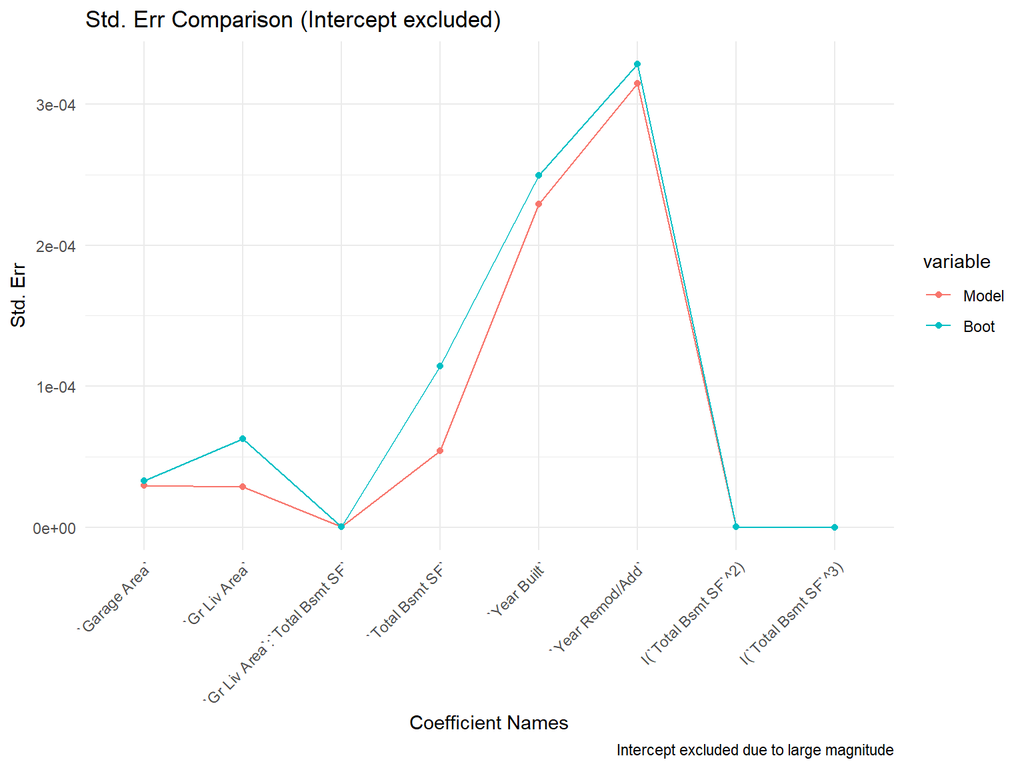

```r
se <- se.compare[se.compare$value < 0.01, ]
ggplot(se) +
  aes(x = Name, y = value, group = variable, color = variable) +
  geom_line() + geom_point() +
  theme_minimal() +
  theme(axis.text.x = element_text(angle = 45, hjust = 1)) +
  labs(x = "Coefficient Names", y = "Std. Err",
       title = "Std. Err Comparison (Intercept excluded)",
       caption = "Intercept excluded due to large magnitude")
```

Your answer:

```
In this model, bootstrapping seems to result in larger standard error that model based does.
```

- Use cross validation to decide which model has a good predictive accuracy. Does the result hold true for the prediction of future data?

Your code:

```r
# MSE
#ames_raw_2009 <- ames_raw_2009[!is.na(ames_raw_2009$SalePrice), ]
sqrt(mean((ames_raw_2009$SalePrice - na.omit(exp(predict(lmfit_2008, ames_raw_2009))))^2))
```

```
## [1] 37685.9
```

Your answer:

- Using `knn.reg` fit KNN regression model. Use cross validation to decide which K to use.

Your code:

```r
# k <- 1:20
# fit_2008.knn <- train(formula = log(SalePrice) ~
#                      `Year Built` + `Year Remod/Add` +
#                      `Gr Liv Area` * `Total Bsmt SF` + `Garage Area` +
#                      I(`Total Bsmt SF`^2) + I(`Total Bsmt SF`^3),
#                    data = ames_raw_2008, method = "knn", na.action = na.exclude,
#                    tuneGrid = expand.grid(k = k),
#                    trControl = trainControl(method = "cv", number = 10))
# print(fit_2008.knn)
## Error: Every row has at least one missing value were found
```

Your answer:

```
Failed to generate model because of NAs in predictors.
```

- Which model performs better on your training data? Which model performs better in your future prediction?

Your code:

```r
#
#
```

Your answer:

```
Please write your answer in full sentences.
```

## Problem Set

### Bootstrap

We will investigate numerically the probability that a bootstrap sample of size n = 100 contains the jth observation. Here j = 4. We repeatedly create bootstrap samples, and each time we record whether or not the fourth observation is contained in the bootstrap sample.

Here is the code to get you going

```r
store <- rep(NA, 10000)
for(i in 1:10000){
  store[i] <- sum(sample (1:100 , rep=TRUE) == 4) > 0
}
mean(store)
```

Comment on the results obtained.

Your code:

```r
a <- 1 - ( 1 - 1/100) ^ 100
cat('Probability of selecting 4th in one bootstrap set: ',a)
```

```
## Probability of selecting 4th in one bootstrap set:  0.6339677
```

```r
m <- rep(NA, 100)
for(k in 1:100){
  store <- rep(NA, 10000)
  for(i in 1:10000){
    store[i] <- sum(sample (1:100 , rep=TRUE) == 4) > 0
  }
  m[k] <- mean(store)
}
mean(m)
```

```
## [1] 0.633417
```

Your answer:

```
The probability of selecting 4th observation in a bootstrap data set is approximately 0.634.
To calculate the probability of one certain observation being included in a bootstrap set, the answer would be [1 - P(not included)^(bootstrap size)], in this case P = 1 - 1/100, bootstrap size (sample 1:100) equal to the original data size (number 1 to 100), and the probability is value 'a' printed above.
If we simulate this process for 10,000 times, the proportion of bootstraps with 4th is on average nearly equal to 0.634 (0.633).
```

### CV

We will now perform cross-validation on a simulated data set. (a) Generate a simulated data set as follows:

```r
set.seed (1)
x <- rnorm (100)
y <- x - 2 * x^2 + rnorm (100)
```

In this data set, what is n and what is p? Write out the model used to generate the data in equation form.

Your code:

```r
n <- 100
p <- 2
```

Your answer:

```
n is 100 as we generate 100 random number under normal distribution.
p is 2 since two predictors are involved: x and x^2.
y = x - 2 * x^2 + error
errors are normally distributed.
```

2. Create a scatterplot of X against Y . Comment on what you find.

Your code:

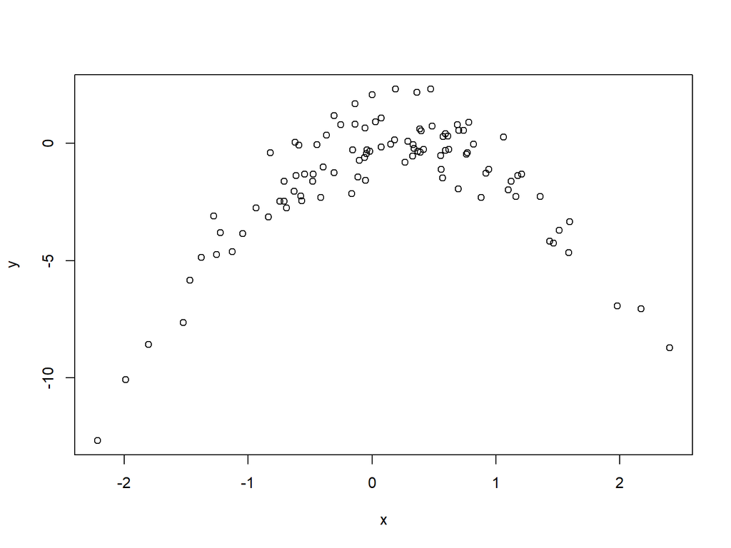

```r
set.seed (1)
x <- rnorm (100)
y <- x - 2 * x^2 + rnorm (100)
plot(x, y)
```

Your answer:

```
X and Y are non-linear. The points form a curve resembling normal distribution but cluster in the middle.
```

3. Set a random seed, and then compute the LOOCV errors that result from fitting the following four models using least squares:
1. $Y = \beta_0 + \beta_1X + \epsilon$
2. $Y = \beta_0 + \beta_1X + \beta_2X^2 + \epsilon$
3. $Y = \beta_0 + \beta_1X + \beta_2X^2 + \beta_3X^3 + \epsilon$
4. $Y = \beta_0 + \beta_1X + \beta_2X^2 + \beta_3X^3 + \beta_4X^4 + \epsilon$.

Note you may find it helpful to use the `data.frame()` function to create a single data set containing both $X$ and $Y$ .

Your code:

```r
set.seed(123)
x <- rnorm (100)
y <- x - 2 * x^2 + rnorm (100)
xy <- data.frame(x, y)
cv.err <- rep(0, 4)

for (i in 1:4){
  glm.fit <- glm(y ~ poly(x, degree = i), data = xy)
  cv.err[i] = cv.glm(xy, glm.fit)$delta[1]
}
cv.err
```

```
## [1] 6.9752118 0.9664678 1.0000174 0.9993215
```

Your answer:

```
LOOCV errors dramatically drop at degree = 2 indicating quadratic fit effectively lowers the error while adding degrees improves little.
```

4. Repeat (c) using another random seed, and report your results. Are your results the same as what you got in (c)? Why?

Your code:

```r
set.seed(16)
x <- rnorm (100)
y <- x - 2 * x^2 + rnorm (100)
xy <- data.frame(x, y)
cv.err <- rep(0, 4)

for (i in 1:4){
  glm.fit <- glm(y ~ poly(x, degree = i), data = xy)
  cv.err[i] = cv.glm(xy, glm.fit)$delta[1]
}
cv.err
```

```
## [1] 10.141384  1.043299  1.102983  4.116629
```

Your answer:

```
The answer is similar to (c). Plus, the error rises in higher polynomial terms confirm the relationship between X and Y is quadratic.
```

5. Which of the models in (c) had the smallest LOOCV error? Is this what you expected? Explain your answer.

Your code:

```r
cv.err
```

```
## [1] 10.141384  1.043299  1.102983  4.116629
```

Your answer:

```
Quadratic model has smallest LOOCV error which matches with expectation since the relationship is visually quadratic in the scatterplot; besides, the formula we use for simulating Y is quadratic.
```

6. Comment on the statistical significance of the coefficient estimates that results from fitting each of the models in (c) using least squares. Do these results agree with the conclusions drawn based on the cross-validation results?

Your code:

```r
#summary(glm.fit)
glm.fit1 <- glm(y ~ poly(x, 1), data = xy)
summary(glm.fit1)
```

```
##
## Call:
## glm(formula = y ~ poly(x, 1), data = xy)
##
## Coefficients:
##             Estimate Std. Error t value Pr(>|t|)
## (Intercept)  -1.9408     0.3008  -6.451 4.22e-09 ***
## poly(x, 1)    7.8522     3.0084   2.610   0.0105 *
## ---
## Signif. codes:  0 '***' 0.001 '**' 0.01 '*' 0.05 '.' 0.1 ' ' 1
##
## (Dispersion parameter for gaussian family taken to be 9.050191)
##
##     Null deviance: 948.58  on 99  degrees of freedom
## Residual deviance: 886.92  on 98  degrees of freedom
## AIC: 508.05
##
## Number of Fisher Scoring iterations: 2
```

```r
glm.fit2 <- glm(y ~ poly(x, 2), data = xy)
summary(glm.fit2)
```

```
##
## Call:
## glm(formula = y ~ poly(x, 2), data = xy)
##
## Coefficients:
##             Estimate Std. Error t value Pr(>|t|)
## (Intercept)  -1.9408     0.1005  -19.30  < 2e-16 ***
## poly(x, 2)1   7.8522     1.0054    7.81 6.79e-12 ***
## poly(x, 2)2 -28.0867     1.0054  -27.93  < 2e-16 ***
## ---
## Signif. codes:  0 '***' 0.001 '**' 0.01 '*' 0.05 '.' 0.1 ' ' 1
##
## (Dispersion parameter for gaussian family taken to be 1.010913)
##
##     Null deviance: 948.576  on 99  degrees of freedom
## Residual deviance:  98.059  on 97  degrees of freedom
## AIC: 289.83
##
## Number of Fisher Scoring iterations: 2
```

```r
glm.fit3 <- glm(y ~ poly(x, 3), data = xy)
summary(glm.fit3)
```

```
##
## Call:
## glm(formula = y ~ poly(x, 3), data = xy)
##
## Coefficients:
##             Estimate Std. Error t value Pr(>|t|)
## (Intercept)  -1.9408     0.1010 -19.217  < 2e-16 ***
## poly(x, 3)1   7.8522     1.0100   7.775 8.49e-12 ***
## poly(x, 3)2 -28.0867     1.0100 -27.809  < 2e-16 ***
## poly(x, 3)3   0.3673     1.0100   0.364    0.717
## ---
## Signif. codes:  0 '***' 0.001 '**' 0.01 '*' 0.05 '.' 0.1 ' ' 1
##
## (Dispersion parameter for gaussian family taken to be 1.020038)
##
##     Null deviance: 948.576  on 99  degrees of freedom
## Residual deviance:  97.924  on 96  degrees of freedom
## AIC: 291.69
##
## Number of Fisher Scoring iterations: 2
```

```r
glm.fit4 <- glm(y ~ poly(x, 4), data = xy)
summary(glm.fit4)
```

```
##
## Call:
## glm(formula = y ~ poly(x, 4), data = xy)
##
## Coefficients:
##             Estimate Std. Error t value Pr(>|t|)
## (Intercept)  -1.9408     0.1015 -19.129  < 2e-16 ***
## poly(x, 4)1   7.8522     1.0146   7.739 1.06e-11 ***
## poly(x, 4)2 -28.0867     1.0146 -27.682  < 2e-16 ***
## poly(x, 4)3   0.3673     1.0146   0.362    0.718
## poly(x, 4)4  -0.3552     1.0146  -0.350    0.727
## ---
## Signif. codes:  0 '***' 0.001 '**' 0.01 '*' 0.05 '.' 0.1 ' ' 1
##
## (Dispersion parameter for gaussian family taken to be 1.029447)
##
##     Null deviance: 948.576  on 99  degrees of freedom
## Residual deviance:  97.798  on 95  degrees of freedom
## AIC: 293.56
##
## Number of Fisher Scoring iterations: 2
```

Your answer:

```
Yes, predictors in model ii are all statistically significant.
The latter two models don't imply significance on degree = 3 or higher term.
```

### Default 1

In Chapter 4, we used logistic regression to predict the probability of default using income and balance on the `Default` data set. We will now estimate the test error of this logistic regression model using the validation set approach. Do not forget to set a random seed before beginning your analysis.

1. Fit a logistic regression model that uses income and balance to predict default.

Your code:

```r
#View(Default)
def_logit.1 <- glm(default ~ balance + income,
                   family = binomial(link = "logit"), Default)
summary(def_logit.1)
```

```
##
## Call:
## glm(formula = default ~ balance + income, family = binomial(link = "logit"),
##     data = Default)
##
## Coefficients:
##               Estimate Std. Error z value Pr(>|z|)
## (Intercept) -1.154e+01  4.348e-01 -26.545  < 2e-16 ***
## balance      5.647e-03  2.274e-04  24.836  < 2e-16 ***
## income       2.081e-05  4.985e-06   4.174 2.99e-05 ***
## ---
## Signif. codes:  0 '***' 0.001 '**' 0.01 '*' 0.05 '.' 0.1 ' ' 1
##
## (Dispersion parameter for binomial family taken to be 1)
##
##     Null deviance: 2920.6  on 9999  degrees of freedom
## Residual deviance: 1579.0  on 9997  degrees of freedom
## AIC: 1585
##
## Number of Fisher Scoring iterations: 8
```

Your answer:

```
The model fit well as shown in parameters and AIC.
```

2. Using the validation set approach, estimate the test error of this model. In order to do this, you must perform the following steps:
1. Split the sample set into a training set and a validation set.

Your code:

```r
set.seed(123)
train <- sample(10000, 5000)
def_train <- Default[train, ]
def_valid <- Default[-train, ]
```

2. Fit a multiple logistic regression model using only the training observations.

Your code:

```r
def_logit.2 <- glm(default ~ balance + income, family = binomial, def_train)
summary(def_logit.2)
```

```
##
## Call:
## glm(formula = default ~ balance + income, family = binomial,
##     data = def_train)
##
## Coefficients:
##               Estimate Std. Error z value Pr(>|z|)
## (Intercept) -1.194e+01  6.451e-01 -18.504  < 2e-16 ***
## balance      5.874e-03  3.362e-04  17.474  < 2e-16 ***
## income       2.210e-05  7.381e-06   2.995  0.00275 **
## ---
## Signif. codes:  0 '***' 0.001 '**' 0.01 '*' 0.05 '.' 0.1 ' ' 1
##
## (Dispersion parameter for binomial family taken to be 1)
##
##     Null deviance: 1429.88  on 4999  degrees of freedom
## Residual deviance:  752.69  on 4997  degrees of freedom
## AIC: 758.69
##
## Number of Fisher Scoring iterations: 8
```

3. Obtain a prediction of default status for each individual in the validation set by computing the posterior probability of default for that individual, and classifying the individual to the default category if the posterior probability is greater than 0.5.

Your code:

```r
def_prob.2 <- predict(def_logit.2, def_valid, type = "response")
def_pred.2 <- ifelse(def_prob.2 < 0.5, "No", "Yes")
# tst.err <- rep(NA, 500)
# for(i in 1:500){
#   tst.err[i] = logical(def_pred.2[i] != def_valid$default)
# }
```

Your answer:

```
Please write your answer in full sentences.
```

4. Compute the validation set error, which is the fraction of the observations in the validation set that are misclassified.

Your code:

```r
table(def_pred.2, def_valid$default)
```

```
##
## def_pred.2   No  Yes
##        No  4808  117
##        Yes   21   54
```

Your answer:

```
Test error = (117 + 21)/5000 = 0.0276 = 2.76%
```

3. Repeat the process in (b) three times, using three different splits of the observations into a training set and a validation set. Comment on the results obtained.

Your code:

```r
set.seed(12)
train <- sample(10000, 5000)
def_train <- Default[train, ]
def_valid <- Default[-train, ]
def_prob.3 <- predict(def_logit.2, def_valid, type = "response")
def_pred.3 <- ifelse(def_prob.3 < 0.5, "No", "Yes")
table(def_pred.3, def_valid$default)
```

```
##
## def_pred.3   No  Yes
##        No  4810  115
##        Yes   19   56
```

```r
set.seed(900)
train <- sample(10000, 5000)
def_train <- Default[train, ]
def_valid <- Default[-train, ]
def_prob.4 <- predict(def_logit.2, def_valid, type = "response")
def_pred.4 <- ifelse(def_prob.4 < 0.5, "No", "Yes")
table(def_pred.4, def_valid$default)
```

```
##
## def_pred.4   No  Yes
##        No  4817  115
##        Yes   18   50
```

```r
set.seed(2000)
train <- sample(10000, 5000)
def_train <- Default[train, ]
def_valid <- Default[-train, ]
def_prob.5 <- predict(def_logit.2, def_valid, type = "response")
def_pred.5 <- ifelse(def_prob.5 < 0.5, "No", "Yes")
table(def_pred.5, def_valid$default)
```

```
##
## def_pred.5   No  Yes
##        No  4793  127
##        Yes   22   58
```

Your answer:

[output not shown]

4. Now consider a logistic regression model that predicts the probability of default using income, balance, and a dummy variable for student. Estimate the test error for this model using the validation set approach. Comment on whether or not including a dummy variable for student leads to a reduction in the test error rate.

Your code:

```r
set.seed(123)
train <- sample(10000, 5000)
def_train <- Default[train, ]
def_valid <- Default[-train, ]
def_logit.dummy <- glm(default ~ balance + income + student, family = binomial, def_train)
def_prob.6 <- predict(def_logit.dummy, def_valid, type = "response")
def_pred.6 <- ifelse(def_prob.6 < 0.5, "No", "Yes")
table(def_pred.6, def_valid$default)
```

```
##
## def_pred.6   No  Yes
##        No  4809  116
##        Yes   20   55
```

Your answer:

[output not shown]

### Default 2

We continue to consider the use of a logistic regression model to predict the probability of default using income and balance on the `Default` data set. In particular, we will now compute estimates for the standard errors of the income and balance logistic regression coefficients in two different ways: (1) using the bootstrap, and (2) using the standard formula for computing the standard errors in the `glm()` function. Do not forget to set a random seed before beginning your analysis.

1. Using the `summary()` and `glm()` functions, determine the estimated standard errors for the coefficients associated with income and balance in a multiple logistic regression model that uses both predictors.

Your code:

```r
def_logit.1 <- glm(default ~ balance + income,
                   family = binomial, Default)
summary(def_logit.1)$coefficients[2:3,2]
```

```
##      balance       income
## 2.273731e-04 4.985167e-06
```

2. Write a function, `boot.fn()`, that takes as input the Default data set as well as an index of the observations, and that outputs the coefficient estimates for income and balance in the multiple logistic regression model.

Your code:

```r
#github @onmee
# boot.fn = function(data, index){
#   default = data$default[index]
#   income = data$income[index]
#   balance = data$balance[index]
#   lr.fit2 = glm(default ~ income + balance, family = binomial)
#   return(summary(def_logit.1)$coefficients[2:3,2])
# }
```

Your answer:

3. Use the boot() function together with your boot.fn() function to estimate the standard errors of the logistic regression coefficients for income and balance.

Your code:

```r
# boot.fn(Default,1:length(Default$default))
# boot(Default,boot.fn,100)
```

Your answer:

```
Please write your answer in full sentences.
```

4. Comment on the estimated standard errors obtained using the glm() function and using your bootstrap function.

Your answer:

```
Please write your answer in full sentences.
```

### Boston housing data set

We will now consider the Boston housing data set, from the ISLR2 library.

1. Based on this data set, provide an estimate for the population mean of medv. Call this estimate $\hat{\mu}$.

Your code:

```r
bos <- Boston
#?Boston
#d <- Default
hat_mu <- mean(bos$medv)
hat_mu
```

```
## [1] 22.53281
```

Your answer:

```
The estimate mean of medv is 22.53281: median value of owner-occupied homes is $22,532.81 on average.
```

2. Provide an estimate of the standard error of $\hat{\mu}$. Interpret this result. Hint: We can compute the standard error of the sample mean by dividing the sample standard deviation by the square root of the number of observations.

Your code:

```r
# lm_bos_medv <- lm(medv ~ 1, bos)
# summary(lm_bos_medv)
medv_sd <- sd(bos$medv)
n_bos <- nrow(bos)
medv_se <- medv_sd / sqrt(n_bos)
medv_se
```

```
## [1] 0.4088611
```

Your answer:

```
The est. SE of hat_mu is 0.4089, same as summarized in null model.
```

3. Now estimate the standard error of $\hat{\mu}$ using the bootstrap. How does this compare to your answer from (b)?

Your code:

```r
#?boot
set.seed(123)
# bootstrap_means <- replicate(10000, mean(sample(bos$medv, replace = TRUE)))
# SE_bootstrap <- sd(bootstrap_means)
# SE_bootstrap
# mean(sample(bos$medv, replace = TRUE))
se_bootstrap <- rep(NA, 10000)
for(i in 1:10000){
  bos_bootstrap <- sample(bos$medv, replace = TRUE)
  se_bootstrap[i] <- sd(bos_bootstrap)/sqrt(n_bos)
}
mean(se_bootstrap)
```

```
## [1] 0.4080448
```

```r
#se_bootstrap <- mean(sd_bootstrap)/sqrt(n_bos)
```

Your answer:

```
The est. SE of hat_mu using bootstrap is 0.4080, this is slightly different from answer in (b)
```

4. Based on your bootstrap estimate from (c), provide a 95% confidence interval for the mean of medv. Compare it to the results obtained using t.test(Boston$medv). Hint: You can approximate a 95% confidence interval using the formula $[\hat{\mu} − 2SE(\hat{\mu}), \hat{\mu} + 2SE(\hat{\mu})]$.

Your code:

```r
t.test(Boston$medv)
```

```
##
##  One Sample t-test
##
## data:  Boston$medv
## t = 55.111, df = 505, p-value < 2.2e-16
## alternative hypothesis: true mean is not equal to 0
## 95 percent confidence interval:
##  21.72953 23.33608
## sample estimates:
## mean of x
##  22.53281
```

```r
ci_medv_bootstrap <- c(hat_mu - 2*se_bootstrap, hat_mu + 2*se_bootstrap)
print(paste('95% CI based on bootstrap estimate: ', ci_medv_bootstrap[1], "," ,ci_medv_bootstrap[2]))
```

```
## [1] "95% CI based on bootstrap estimate:  21.7858181162323 , 21.7094863982214"
```

Your answer:

[output not shown]

5. Based on this data set, provide an estimate, $\hat{\mu}_{med}$, for the median value of medv in the population.

Your code:

```r
median.medv <-  median(Boston$medv)
cat("Est. Median of medv: ", median.medv)
```

```
## Est. Median of medv:  21.2
```

Your answer:

```
The estimated median for medv is 21.2.
```

6. We now would like to estimate the standard error of $\hat{\mu}_{med}$. Unfortunately, there is no simple formula for computing the standard error of the median. Instead, estimate the standard error of the median using the bootstrap. Comment on your findings.

Your code:

```r
se_med_bootstrap <- sd(replicate(10000, median(sample(bos$medv, replace = TRUE))))
cat("SE of median (bootstrap): ", round(se_med_bootstrap,4))
```

```
## SE of median (bootstrap):  0.3793
```

Your answer:

```
SE of median medv is approximately 0.38 using bootstrap.
```

7. Based on this data set, provide an estimate for the tenth percentile of medv in Boston census tracts. Call this quantity $\hat{\mu}_{0.1}$. (You can use the quantile() function.)

Your code:

```r
quantile(bos$medv, 0.1)
```

```
##   10%
## 12.75
```

Your answer:

```
The 10th percentile value of medv is 12.75.
```

8. Use the bootstrap to estimate the standard error of $\hat{\mu}_{0.1}$. Comment on your findings.

Your code:

```r
se_quan_bootstrap <- sd(replicate(10000, quantile(sample(bos$medv, replace = TRUE), 0.1)))
cat('SE of quantile (bootstrap): ' ,round(se_quan_bootstrap, 4))
```

```
## SE of quantile (bootstrap):  0.501
```

Your answer:

[output not shown]

## Additional Material

### Predictive Modeling Platforms in R

There are few platforms in R that does predictive modeling. These platforms are wrappers around other packages that makes it easy to do routine tasks.

- mlr3 (https://mlr3book.mlr-org.com)
- tidymodels (https://www.tidymodels.org/)
- caret (https://topepo.github.io/caret/)
- h2o (https://docs.h2o.ai/h2o/latest-stable/h2o-r/docs/index.html)

```r
# split the data
index <- sample(1:nrow(ames_raw), 0.7*nrow(ames_raw))
vars <- c("SalePrice","Lot Area","Gr Liv Area","Full Bath")
train <- ames_raw[ index, vars]
test  <- ames_raw[-index, vars]
colnames(train) <- make.names(colnames(train))
colnames(test)  <- make.names(colnames(test))

# mlr3 TaskRegr
train$SalePrice <- log(train$SalePrice)
```

#### Resampling using [mlr3](https://mlr3book.mlr-org.com)

In MLR3 resampling for CV is

```r
mlr_resamplings$get("cv")
rsmp("cv")
```

resampling for bootstrap is

```r
mlr_resamplings$get("bootstrap")
rsmp("bootstrap")
```

They are called using `resample` function

```r
# load packages and data
library(mlr3)
library(mlr3learners)
# fit a model
task <- as_task_regr(train, target ="SalePrice",id = "ames_raw")
learner <- lrn("regr.lm", predict_type = "response")
resampler = rsmp("cv")

# Explicitly instantiate the resampling for this task for reproduciblity
set.seed(123)
resampler$instantiate(task)

rr = resample(task, learner, resampler)
```

[output not shown]

```r
rr$aggregate()
```

```
##   regr.mse
## 0.08085721
```

```r
pred = rr$prediction()

# Repeat resampling with featureless learner
rr_featureless = resample(task, lrn("regr.featureless"), resampler)
```

[output not shown]

```r
# Convert results to BenchmarkResult, then combine them
bmr1 = as_benchmark_result(rr)
bmr2 = as_benchmark_result(rr_featureless)
bmr1$aggregate()
```

```
##    nr  task_id learner_id resampling_id iters   regr.mse
## 1:  1 ames_raw    regr.lm            cv    10 0.08085721
## Hidden columns: resample_result
```

#### Resampling using [tidymodels](https://www.tidymodels.org/)

```r
# load packages and data
library(tidymodels)
library(dotwhisker)
# Setup the model
rec <- recipe(SalePrice ~ ., data = train)
clf <- linear_reg()

folds <- vfold_cv(train, v = 10)
control <- control_resamples(save_pred = TRUE)

wflow <- workflow() %>%
         add_recipe(rec) %>%
         add_model(clf)

# fit the models
lm_fit_rsmpl <- wflow %>% fit_resamples(folds,control=control)

collect_metrics(lm_fit_rsmpl)
```

```
## # A tibble: 2 × 6
##   .metric .estimator  mean     n std_err .config
##   <chr>   <chr>      <dbl> <int>   <dbl> <chr>
## 1 rmse    standard   0.283    10 0.00883 Preprocessor1_Model1
## 2 rsq     standard   0.522    10 0.0194  Preprocessor1_Model1
```

```r
prediction=collect_predictions(lm_fit_rsmpl)
```

#### Resampling using caret

```r
# load packages and data
library(caret)

# fit the models
cv <- trainControl(method = "cv", number = 5)
lm_model <- train(SalePrice ~ ., data = train, method = "lm", trControl = cv)

prediction=predict(lm_model,newdata = test)
```

#### Resampling using h2o

#### Starting H2O

To use H2O you need to instantiate it.

```r
library("h2o")
# nthreads specifies number of threads. -1 means use all the CPU cores.
# max_mem_size specifies the maximum amount of RAM to use.
localH2O <- h2o.init(nthreads = -1, max_mem_size="4g")
```

#### Serving the data to H2O

Since H2O is not in R, you need to tell it to use your data.

```r
train_hf <- as.h2o(train)
test_hf <- as.h2o(test)
```

##### Cross validation

You can use K fold cross validation by specifying an integer to nfolds option. With cross-validated model building, H2O builds K+1 models: K cross-validated model and 1 overarching model over all of the training data.

Fitting GLM using 10 fold cross validation.

```r
gaussian.fit.cv = h2o.glm(y = "SalePrice",                               #response variable
                       x = c("SalePrice","Lot.Area","Gr.Liv.Area","Full.Bath"),
                          training_frame = train_hf, family = "gaussian",lambda = 0, nfolds = 10)
gaussian.fit.cv
```

```r
boxplot(t(sapply(sapply(gaussian.fit.cv@model$cross_validation_models, `[[`, "name"), function(x) h2o.coef(h2o.getModel(x)))),
        names = NULL)
points(1:4, coef(gaussian.fit.cv@model), pch = "X", col = "red")
abline(h = 0, col = "blue")
```